# Quick start for identifying conserved cell type in one minitues

Jiang junyao

2025-07-11

# introduction

This tutorial is made for users who want to quickly use CACIMAR to identify conserved celltypes based on scRNA-seq data. Input of this part is seurat object of different species.

```r
library(CACIMAR)
```

We load the test data by providing a subsetted Seurat object of mouse and zebrafish, as obtained from the [paper](https://pubmed.ncbi.nlm.nih.gov/33004674/), in order to demonstrate the API and utility of CACIAMR.

```r
load(system.file("extdata", "cross_species_small.rda", package = "CACIMAR"))
```

To identify conserved cell types and their corresponding markers, it is necessary to first identify markers specific to each individual cell type. CACIMAR calculates the power of markers separately in each species to avoid the batch effect between species.

```r
marker_spec1 = Identify_Markers(mm_small,cluster_column_use = 'cell_type')
```

```
## [1] "Activated MG"
## [1] "GABAergic AC"
## [1] "Glycinergic AC"
## [1] "Resting MG"
## [1] "Rods"
## [1] "Activated MG" "0"            "100"
## [1] "GABAergic AC" "0"            "100"
## [1] "Glycinergic AC" "0"              "100"
## [1] "Resting MG" "0"          "100"
## [1] "Rods" "0"    "100"
```

```r
marker_spec2 = Identify_Markers(zf_small,cluster_column_use = 'cell_type')
```

```
## [1] "Activated MG"
## [1] "GABAergic AC"
## [1] "Glycinergic AC"
## [1] "Resting MG"
## [1] "Rods"
## [1] "Activated MG" "0"            "100"
## [1] "GABAergic AC" "0"            "100"
## [1] "Glycinergic AC" "0"              "100"
## [1] "Resting MG" "0"          "100"
## [1] "Rods" "0"    "100"
```

Then, we identify conserved cell types based on the marker power in each cluster. ‘marker_spec1’ and ‘marker_spec2’ are data.frame of marker power, and should contain three columns **gene**, **power**, and **cluster**.

The ouput of this part is ‘conserved_celltype’. ‘conserved_celltype’ is a list contains three elements, first element is the detailed conserved analysis, including, all gene number in each cell type pair, conserved gene number in each cell type pair, and conserved gene name in each cell type pair. The second element is the conservation score among all cell type pairs.

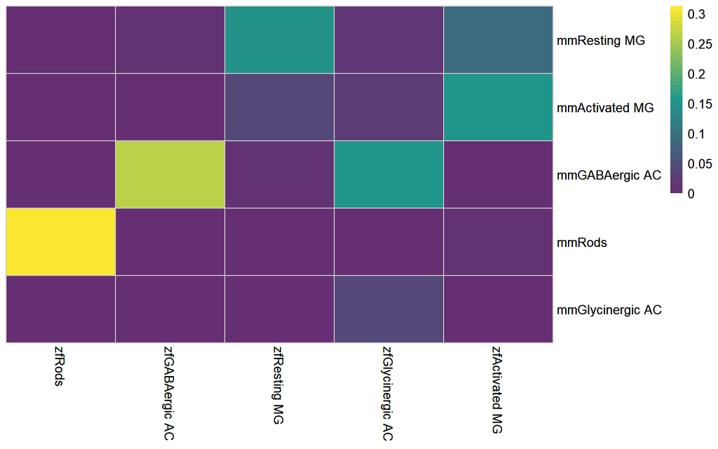

```r
conserved_celltype <- Identify_ConservedCellTypes(OrthG_Mm_Zf, marker_spec1, marker_spec2,'mm','zf')
CSCT_plot = conserved_celltype[[2]]
CSCT_plot = CSCT_plot[grep('mm',rownames(CSCT_plot)),grep('zf',colnames(CSCT_plot))]
### show the CSCT value with a heatmap
Heatmap_Cor(CSCT_plot,cluster_cols=F, cluster_rows=F,Color1 = c(rgb(102/255,46/255,115/255),rgb(31/255,153/255,139/255),rgb(251/255,232/255,48/255)))
```

Using CSCT as the distance matrix, we can further construct cell type phylogenetic trees.

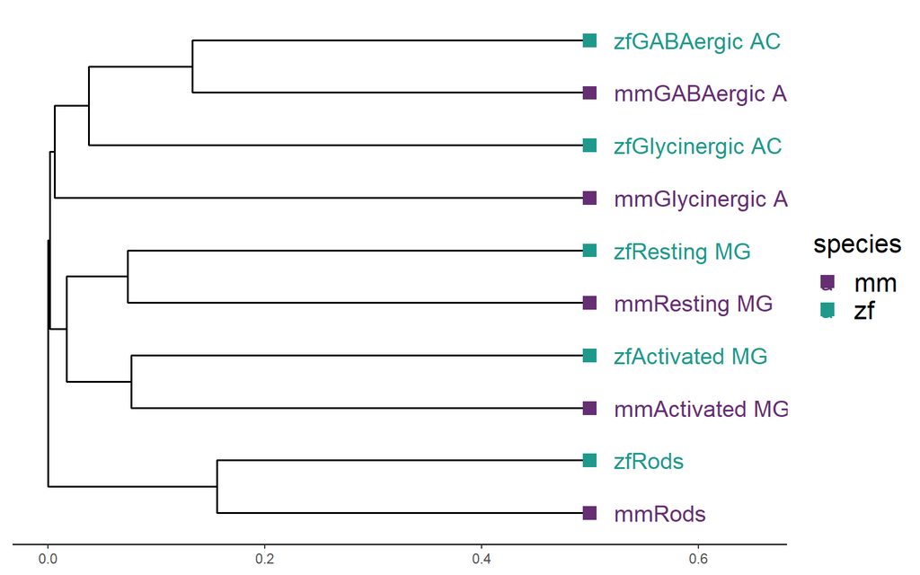

```r
dist_matrix <- conserved_celltype[[2]]
species.vector <- substr(rownames(dist_matrix), 1, 2)
species_CellType_Tree <- Plot_Species_CellType_Tree(dist_matrix = dist_matrix, species.vector = species.vector, hcluster.method = "average", geom_nodepoint = 0, layout.tree = "rectangular", offset = 0.02, tiplab.size = 5, tippoint.shape = 22, tippoint.shape.size = 4)
species_CellType_Tree$Plot
```

Based on the CSCT above, we further identify conserved celltypes

```r
conserved_celltype = identify_conserved_pair(CSCT_plot)
print(conserved_celltype)
```

```
## [1] "mmActivated MG-zfActivated MG" "mmGABAergic AC-zfGABAergic AC"
## [3] "mmRods-zfRods"
```

Then we can identify conserved markers among these conserved cell type pairs.

```r
conserved_markers = identify_conserved_marker(OrthG_Mm_Zf,marker_spec1, marker_spec2,
                                               Species_name1 = 'mm',
                                               Species_name2 = 'zf',conserved_celltype_pair = conserved_celltype)
head(conserved_markers)
```

```
##                    mm_conserved_marker zf_conserved_marker   mm_cluster
## mm_zf_1T1G721       ENSMUSG00000008683  ENSDARG00000010160 Activated MG
## mm_zf_1T1G1070      ENSMUSG00000017009  ENSDARG00000059906 Activated MG
## mm_zf_1T1G1177      ENSMUSG00000018593  ENSDARG00000019353 Activated MG
## mm_zf_1T1G1832      ENSMUSG00000021250  ENSDARG00000031683 Activated MG
## mm_zf_1T1G2558...5  ENSMUSG00000023944  ENSDARG00000029150 Activated MG
## mm_zf_1T1G3476      ENSMUSG00000026701  ENSDARG00000043511 Activated MG
##                      zf_cluster
## mm_zf_1T1G721      Activated MG
## mm_zf_1T1G1070     Activated MG
## mm_zf_1T1G1177     Activated MG
## mm_zf_1T1G1832     Activated MG
## mm_zf_1T1G2558...5 Activated MG
## mm_zf_1T1G3476     Activated MG
```

Additionally, it is possible to conduct unbiased analysis of conserved markers in all pairs of cell types.

```r
combination=combn(c(unique(marker_spec1$cluster),unique(marker_spec2$cluster)),2)
combination[,1] = paste0('mm',combination[,1])
combination[,2] = paste0('zf',combination[,2])
unbiased_markers = identify_conserved_marker(OrthG_Mm_Zf,marker_spec1, marker_spec2,
                                               Species_name1 = 'mm',
                                               Species_name2 = 'zf',conserved_celltype_pair = paste0(combination[,1],'-',combination[,2]))
head(unbiased_markers)
```

```
##                mm_conserved_marker zf_conserved_marker mm_cluster zf_cluster
## mm_zf_1T1G1177  ENSMUSG00000018593  ENSDARG00000019353 Resting MG Resting MG
## mm_zf_1T1G1531  ENSMUSG00000020423  ENSDARG00000020298 Resting MG Resting MG
## mm_zf_1T1G1832  ENSMUSG00000021250  ENSDARG00000031683 Resting MG Resting MG
## mm_zf_1T1G2279  ENSMUSG00000022528  ENSDARG00000006514 Resting MG Resting MG
## mm_zf_1T1G3476  ENSMUSG00000026701  ENSDARG00000043511 Resting MG Resting MG
## mm_zf_1T1G6196  ENSMUSG00000035805  ENSDARG00000063026 Resting MG Resting MG
```

Finally, we provide inner functions to visualize conserved markers in conserved cell types across species.

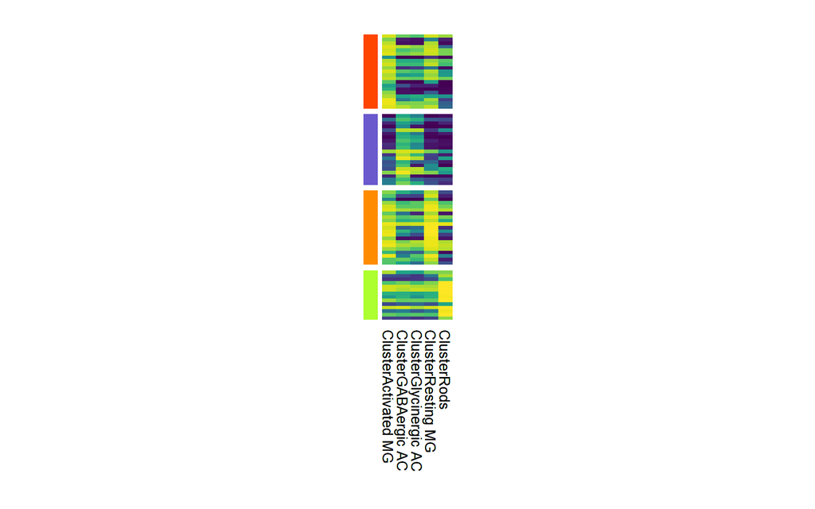

```r
marker_spec_visualize1 = marker_spec1[conserved_markers$mm_conserved_marker,4:9]
marker_spec_visualize1 = marker_spec_visualize1[order(marker_spec_visualize1[,1]),]
Plot_MarkersHeatmap(marker_spec_visualize1,cellheight = 2.5,cellwidth = 10,border_color=NA,show_colnames = TRUE)
```

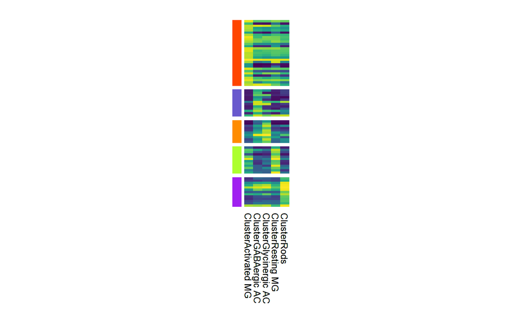

```r
marker_spec_visualize2 = marker_spec2[conserved_markers$zf_conserved_marker,4:9]
marker_spec_visualize2 = marker_spec_visualize2[order(marker_spec_visualize2[,1]),]
Plot_MarkersHeatmap(marker_spec_visualize2,cellheight = 2.5,cellwidth = 10,border_color=NA,show_colnames = TRUE)
```